# Prediction Assignment

## Background

Using devices such as Jawbone Up, Nike FuelBand, and Fitbit it is now possible to collect a large amount of data about personal activity relatively inexpensively. These type of devices are part of the quantified self movement – a group of enthusiasts who take measurements about themselves regularly to improve their health, to find patterns in their behavior, or because they are tech geeks. One thing that people regularly do is quantify how much of a particular activity they do, but they rarely quantify how well they do it. In this document, our goal will be to use data from accelerometers on the belt, forearm, arm, and dumbell of 6 participants. They were asked to perform barbell lifts correctly and incorrectly in 5 different ways. More information is available from the website here: http://groupware.les.inf.puc-rio.br/har (see the section on the Weight Lifting Exercise Dataset).

## Executive Summary

In this document we will describe the process of generating a prediction model to predict user activity quality using the Random Forest statistic model. We will show we can fit a model which can predict with a sample error of less than 2%.

## Download and Load Data

The training data for this project are available here: https://d396qusza40orc.cloudfront.net/predmachlearn/pml-training.csv

The test data are available here: https://d396qusza40orc.cloudfront.net/predmachlearn/pml-testing.csv

```r
download.file("https://d396qusza40orc.cloudfront.net/predmachlearn/pml-training.csv", destfile = "Prediction/pml-training.csv")
download.file("https://d396qusza40orc.cloudfront.net/predmachlearn/pml-testing.csv", destfile = "Prediction/pml-testing.csv")
```

```r
training <- read.csv("pml-training.csv", na.strings=c("","#DIV/0!","NA"))
testing <- read.csv("pml-testing.csv", na.strings=c("","#DIV/0!","NA"))
```

## Exploratory Data

```r
dim(training);dim(testing)
```

```
## [1] 19622   160
```

```
## [1]  20 160
```

## Data Overview

First, let’s understand what kind of variables we have (using the help of [this paper](http://groupware.les.inf.puc-rio.br/public/papers/2013.Velloso.QAR-WLE.pdf)):

Understanding the columns:  
Euler angles (roll, pitch, yaw) per sensors (arm,belt,dumbbel,forearm) = 12 columns  
Euler angles (roll, pitch, yaw) per sensors (arm,belt,dumbbel,forearm) per feature (mean, variance, standard deviation, max, min, amplitude, kurtosis and skewness) = 96 features.  
Raw accelerometer, gyroscope and magnetometer per sensor = 36  
total and variance for the accelerometer per sensors = 8  
Additional columns: X - serail number, User_name, raw_timestamp_part_1, raw_timestamp_part_2, cvtd_timestamp, new_window, num_window, classe

Exploring observations:  
Let’s first make sure to handle NA values:

```r
ncol(training[,colSums(is.na(training))> (nrow(training)*0.9)])
```

```
## [1] 100
```

We see there are 100 features with over 90% of the data NA. As such features wouldn’t contribute our prediction, we will remove them from our training dataset.

We can also remove columns 1:7 as they are not related to the prediction.

```r
training <- training[,-c(1:7)]
colHighNa <- names(training[,colSums(is.na(training))> (nrow(training)*0.9)])
training <- training[,!names(training) %in% colHighNa]
```

## Feature selection

We are left with 53 features; we will try to reduce this number by removing highly correlated features. We will cutoff the features on 70% correlation.

```r
library(caret)
set.seed(24356)
correlationMatrix <- cor(training[,c(-53)])
colCor <- findCorrelation(correlationMatrix, cutoff = 0.70, exact=TRUE)
par(mfrow=c(1,2))
training <- training[,-colCor]
```

## Cross Validation Datasets

We will now partition our training set into trainingA (75% of data) and testingA (25% of data). The trainingA dataset will be used for the prediction analysis that will be cross-validated against testingA dataset.

```r
inTrain <- createDataPartition(y=training$classe, p=0.75, list=FALSE)
trainingA <- training[inTrain,]
testingA <- training[-inTrain,]
dim(trainingA)
```

```
## [1] 14718    31
```

## Random Forest

### Fit the model and check sample error

```r
library(randomForest)
```

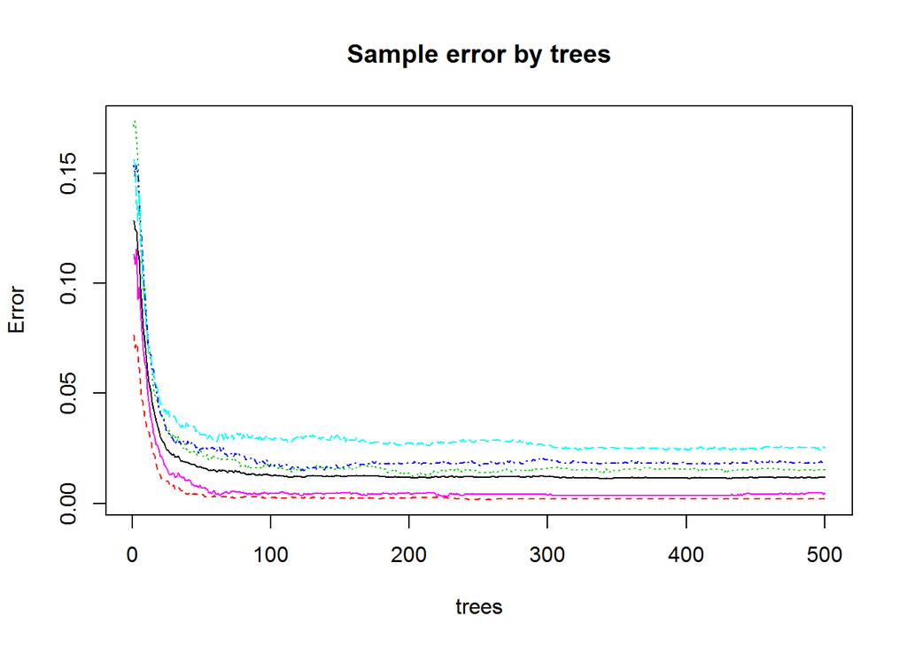

```r
fit_rf <- randomForest(classe~.,trainingA,ntree=500)
par(mfrow=c(1,1))
plot(fit_rf, main="Sample error by trees")
```

```r
#varImpPlot(fit_rf)
fit_rf
```

```
##
## Call:
##  randomForest(formula = classe ~ ., data = trainingA, ntree = 500)
##                Type of random forest: classification
##                      Number of trees: 500
## No. of variables tried at each split: 5
##
##         OOB estimate of  error rate: 1.18%
## Confusion matrix:
##      A    B    C    D    E class.error
## A 4177    6    0    1    1 0.001911589
## B   34 2804    6    0    4 0.015449438
## C    1   30 2519   16    1 0.018698870
## D    0    0   54 2351    7 0.025290216
## E    0    2    3    8 2693 0.004804139
```

### Cross validate Model

We will now test the model we’ve fitted against the testingA dataset:

```r
predTestingA <- predict(fit_rf, newdata=testingA)
confusionMatrix(predTestingA, testingA$classe)
```

```
## Confusion Matrix and Statistics
##
##           Reference
## Prediction    A    B    C    D    E
##          A 1392   10    0    0    0
##          B    3  931    9    0    0
##          C    0    6  843   23    0
##          D    0    2    3  780    5
##          E    0    0    0    1  896
##
## Overall Statistics
##
##                Accuracy : 0.9874
##                  95% CI : (0.9838, 0.9903)
##     No Information Rate : 0.2845
##     P-Value [Acc > NIR] : < 2.2e-16
##
##                   Kappa : 0.984
##  Mcnemar's Test P-Value : NA
##
## Statistics by Class:
##
##                      Class: A Class: B Class: C Class: D Class: E
## Sensitivity            0.9978   0.9810   0.9860   0.9701   0.9945
## Specificity            0.9972   0.9970   0.9928   0.9976   0.9998
## Pos Pred Value         0.9929   0.9873   0.9667   0.9873   0.9989
## Neg Pred Value         0.9991   0.9955   0.9970   0.9942   0.9988
## Prevalence             0.2845   0.1935   0.1743   0.1639   0.1837
## Detection Rate         0.2838   0.1898   0.1719   0.1591   0.1827
## Detection Prevalence   0.2859   0.1923   0.1778   0.1611   0.1829
## Balanced Accuracy      0.9975   0.9890   0.9894   0.9839   0.9971
```

Confusion Matrix shows a 99% accuracy for our model when used against our testingA dataset.s

### Prediction against testing dataset

```r
predTesting <- predict(fit_rf,newdata=testing)
predTesting
```

```
##  1  2  3  4  5  6  7  8  9 10 11 12 13 14 15 16 17 18 19 20
##  B  A  B  A  A  E  D  B  A  A  B  C  B  A  E  E  A  B  B  B
## Levels: A B C D E
```